# Reproductible Research - Course Project 1

ezornoff

06/08/2020

## Reading the file and processing

```r
data = read.csv("activity.csv")
data$date = as.Date(data$date, format = "%Y-%m-%d")
data$interval = as.factor(data$interval)
```

## What is the total number of steps per day?

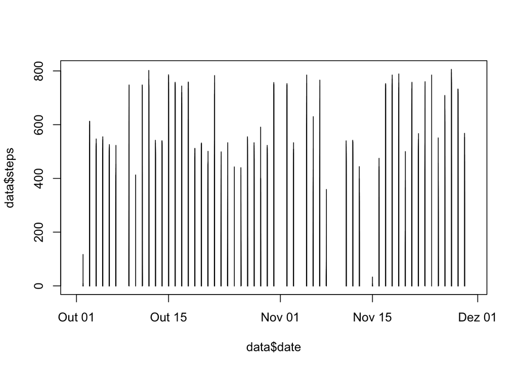

```r
# plotting the number of steps per day

plot(data$date, data$steps, type = "h")
```

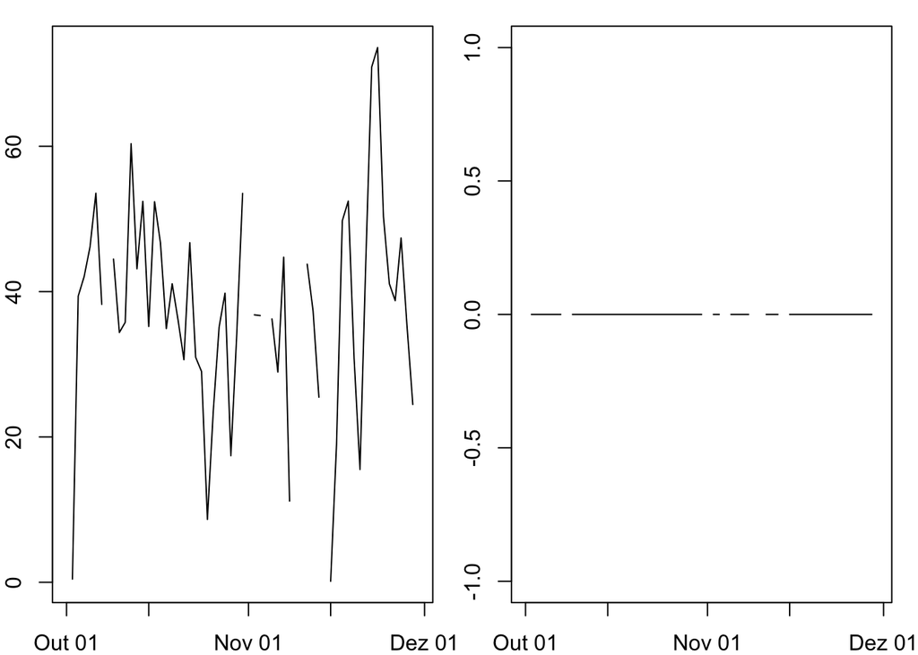

```r
# calculating the mean and median for each day

mn = with(data, tapply(steps, date, mean))
med = with(data, tapply(steps, date, median))
dat = unique(data$date)
data1 = data.frame(date = dat, mean = mn, median = med)

# plotting the mean

par(mfrow = c(1,2), mar = c(2, 2, 1, 1))
with(data1, plot(date, mean, pch = 19, type = "l", ylab = "steps"))
with(data1, plot(date, median, pch = 19, type = "l"))
```

There’s 8 days that the all the observations are NA.

```r
subset(data1, is.na(data1$mean))
```

```
##                  date mean median
## 2012-10-01 2012-10-01   NA     NA
## 2012-10-08 2012-10-08   NA     NA
## 2012-11-01 2012-11-01   NA     NA
## 2012-11-04 2012-11-04   NA     NA
## 2012-11-09 2012-11-09   NA     NA
## 2012-11-10 2012-11-10   NA     NA
## 2012-11-14 2012-11-14   NA     NA
## 2012-11-30 2012-11-30   NA     NA
```

All the median of the other days are equal to 0, because the non zero observations are less frequent than the zero observations.

```r
d = "2012-11-03"
z = sum(data$steps[data$date == d] == 0)
nZ = sum(!data$steps[data$date == d] == 0)
```

For example, on day 2012-11-03 there is 198 observations and only 90 non zero obsevations

## What is the average daily pattern?

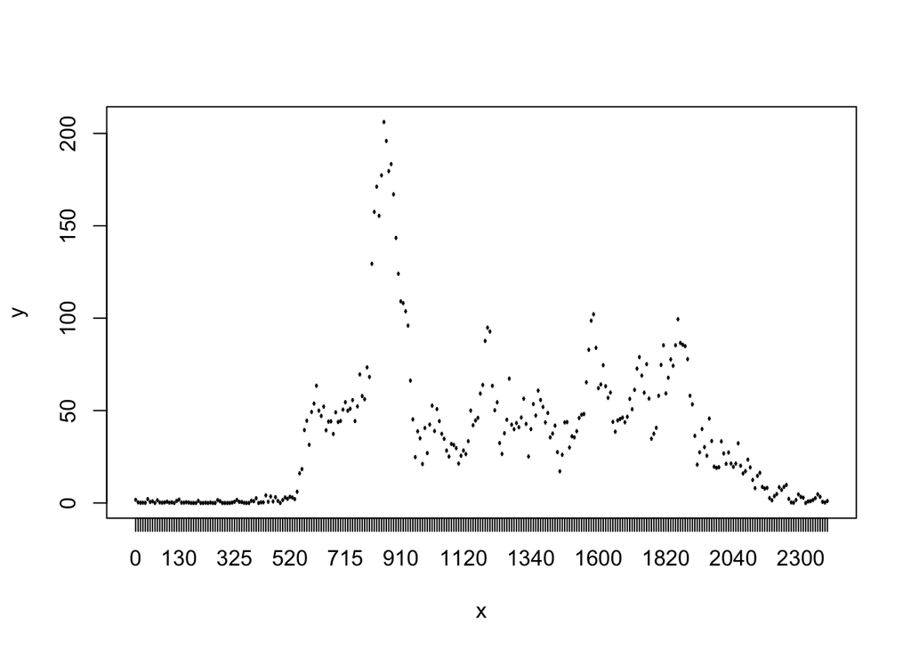

```r
mn_int = with(data, tapply(steps, interval, mean, na.rm = TRUE))
pat = data.frame(interval = unique(data$interval), mean = mn_int)
with(pat, plot(interval, mn_int, type = "l"))
```

```r
m = max(mn_int)
int = pat$interval[which.max(mn_int)]
```

The maximum number of steps were on interval 835 and the max average number of steps were 206.1698113

## Imputting missing values

```r
n = sum(is.na(data$steps))
```

The total number of missing (NA) step values is 2304.

The strategy to add values to the NA observations is to use the mean for the same 5 minute interval. This was choosen because there are days, actually 8 days, with all the observations equals NA.

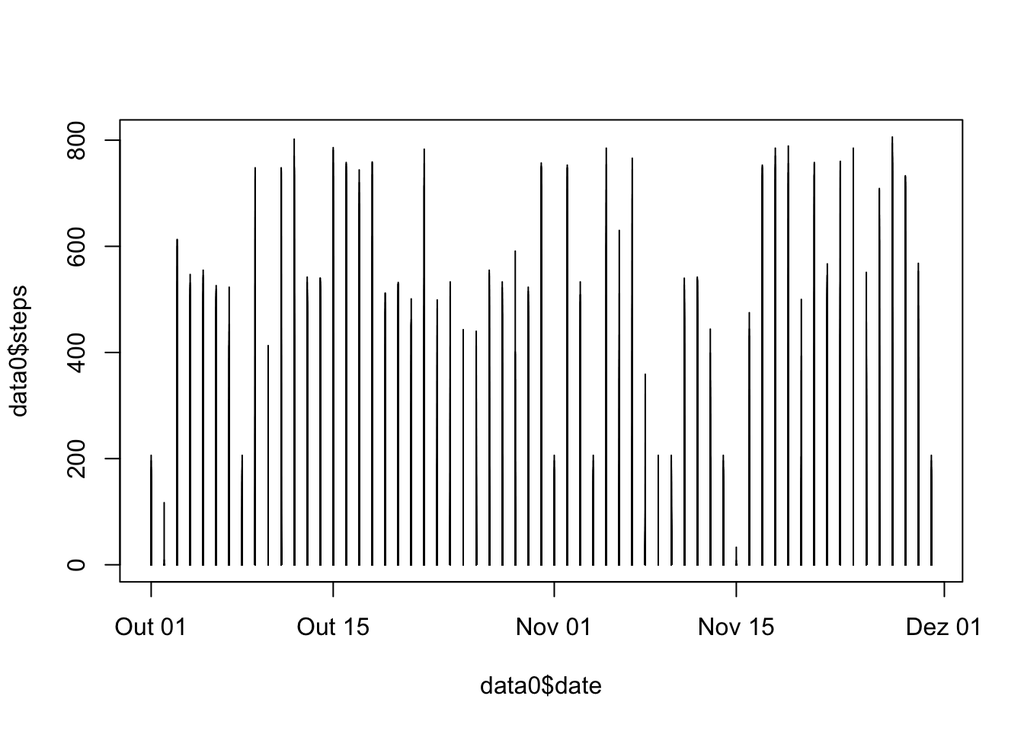

```r
# creating new data frame
data0 = data

# inserting missing values
for (i in 1:nrow(data0)) {
        if (is.na(data0$steps[i])) {
                data0$steps[i] = mean(data0$steps[data0$interval == data0$interval[i]],                        na.rm = TRUE)
        }
}

# plotting the number of steps per day
plot(data0$date, data0$steps, type = "h")
```

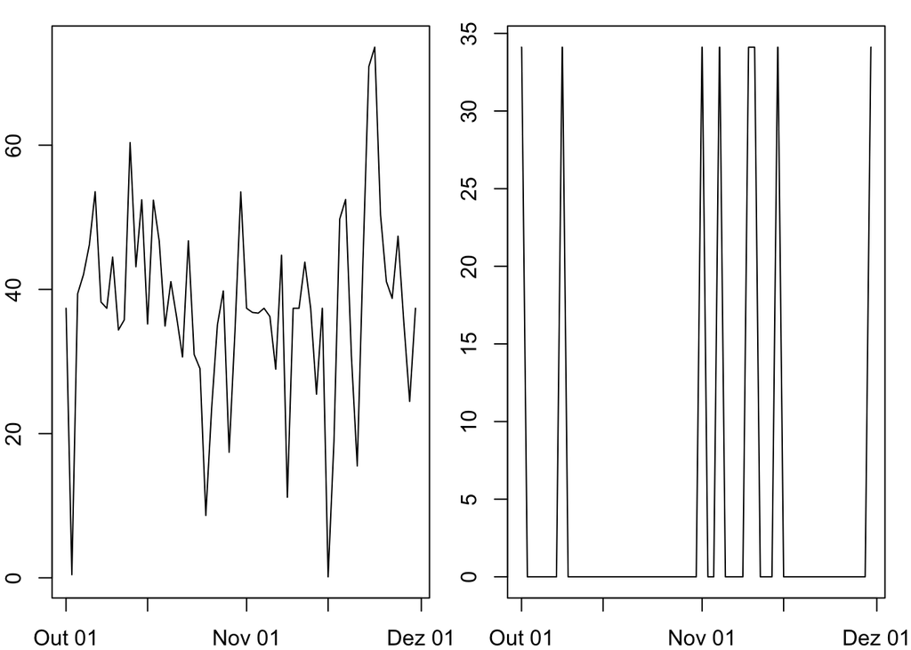

```r
# calculating the mean and median for each day

mn0 = with(data0, tapply(steps, date, mean))
med0 = with(data0, tapply(steps, date, median))
dat0 = unique(data0$date)
data2 = data.frame(date = dat0, mean = mn0, median = med0)

# plotting the mean

par(mfrow = c(1,2), mar = c(2, 2, 1, 1))
with(data2, plot(date, mean, pch = 19, type = "l"))
with(data2, plot(date, median, pch = 19, type = "l"))
```

As we can see on the graphics, all the days now have values. The values for the days that were completly without observations (NA) are equal to the gereral mean. The median for these days have a positive and equal value because there are no more zeros on the observations for these days.

## Are there diferences in activity patterns between weekdays and weekends?

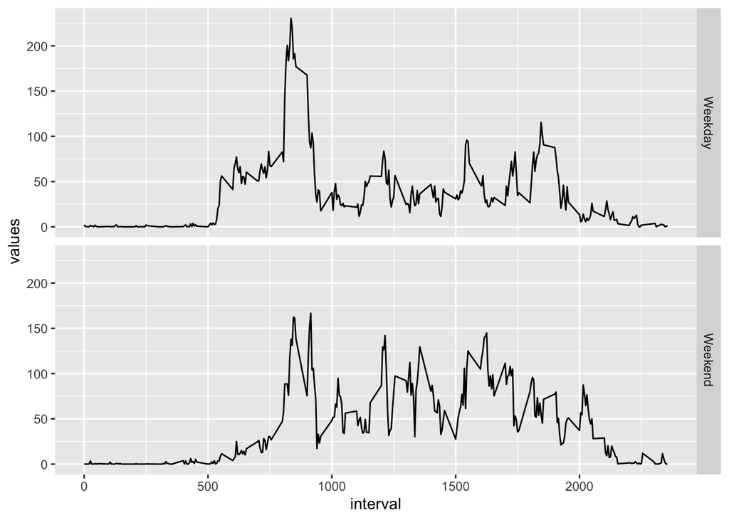

```r
# adding a column with the weekday
data0$weekday = weekdays(data0$date, abbreviate = TRUE)

# defining factor weekday or weekend
for (i in 1:nrow(data0)) {
        if (data0$weekday[i] == "Sáb" || data0$weekday[i] == "Dom") {data0$week[i] =                    "Weekend"} else {data0$week[i] = "Weekday"}
}
data0$week = as.factor(data0$week)

# calculating the mean per type of day and interval and setting the data frame
mn1 = with(data0, tapply(steps, list(interval, week), mean))
mn1 = as.data.frame(mn1)
int1 = rownames(mn1)
mn1 = stack(mn1)
mn1$interval = as.numeric(int1)

# gerenating the graphic
library(ggplot2)
qplot(interval, values, data = mn1, facets = ind~., geom = "line")
```

As we can see from the graphic above on weekdays there’s more step in average on the begining and on the end of the intervals, but on the middle range of the intervals it seems that there’s more steps on avarage on weekends.